# Juzgamiento de hipótesis

Jairo Enrique Alba

2/12/2022

# Juzgamiento o prueba de hipótesis.

Consiste en una metodología paso a paso que nos permitirá hacer inferencias con respecto al valor específico de un parámetro de la población mediante el análisis de diferencias entre los resultados que observamos de la realidad (obtenidos de la muestra) y los resultados que esperariamos obtener si alguna hipótesis subyacente fuera verdadera.

Constituye una técnica provechosa para analizar diferencias y tomar decisiones.

# Juzgamiento o prueba de hipótesis.

Se parte de algún tipo de distribución. Por ejemplo:

- Uniforme: todos los eventos son igualmente probables.
- Normal: No todos los eventos son igualmente probables. Ejemplos: altura, peso, inteligencia, extroversión, rendimiento académico, tiempo en que duran los estudiantes en prepararsen para un examen, …

# Distribución normal.

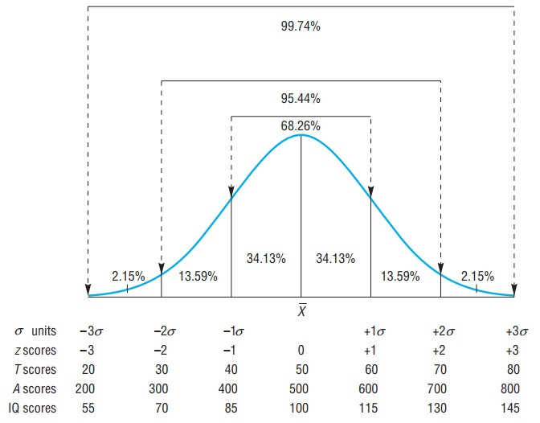

Distribución normal

# Aproximación a una distribución normal.

Siempre que un conjunto de datos se distribuya de manera aproximada a una distribución normal se pueden analizar teniendo en cuenta las propiedades de dicha distribución.

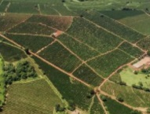

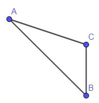

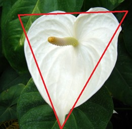

# Ejemplo de un juzgamiento de hipótesis.

Supongamos que el tiempo necesario para prepararse para un examen es de 8 horas. Un grupo de cientificos diseñan una píldora para disminuir el tiempo necesario para prepararse para dicho examen.

Se toma una muestra de tres estudiantes a los cuales se les suministra voluntariamente dicha píldora, los cuales preparan el examen en solo 6 horas.

**¿FUNCIONA O NO FUNCIONA LA PÍLDORA?**

Con lo visto en la muestra parece funcionar.

Pero CUIDADO!

Ya que si el tiempo necesario para preparar el examen se distribuía de manera normal, existe la probabilidad de que las tres personas que seleccione en la muestra se ubicaban en la cola inferior, es decir sin tomar dicha píldora iban a gastar ese tiempo.

En otras palabras **la píldora no funciona solo que hubo un error de muestreo**

# Ilustración de la situación.

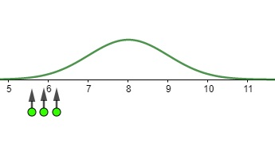

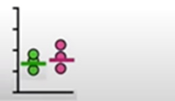

# Comparación con la distribución normal

Conociendo el área dela cola izquierda, puedo conocer la probabilidad de que justo elija al azar personas que se encuentren de 6 horas para abajo.

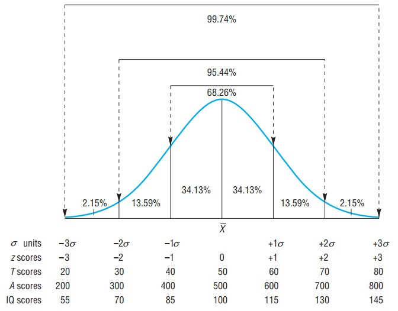

# Comparación con la distribución normal

Existe la probabilidad de 2.15% de que justo elija alguien de que estaba por abajo de 6 horas.

Entonces se dice que la píldora funciona con un margen de error del 2.15%.

En función de lo anterior siempre se debe hablar del margen de error, al decir que la píldora funciona o no funciona. Para este caso la píldora funciona con un error del 2.15%.

La situación anterior se puede dar en:

- Tratamiento psicológico.
- Método para aumentar la motivación.
- Método de estudio para aprender más rápido.
- Método para disminuir la ansiedad.
- …

# ¿Que se debe hacer al analizar los resultados?

En el momento de analizar los resultados en algún tratamiento siempre se deben comparar con los resultados que uno esperaría simplemente por azar.

Siempre se debe dudar y mirar los errores.

Entonces surgen las preguntas:

- ¿Cuando se considera que los resultados se deben al azar?
- ¿Cuando se considera que los resultados no se deben al azar?

Veamos!

# Hablemos de juzgamiento o pruebas de hipótesis.

Las pruebas de hipótesis dependen entre otras cosas de dos aspectos importantes:

- Resultados de las muestras.
- Resultados esperados si una hipótesis determinada fuera cierta.

**Y el objetivo de las pruebas de hipótesis es examinar los resultados que se obtienen en un estudio y evaluar cual es la probabilidad de que esos resultados que se estan obteniendo hayan sido simplemente por azar.**

Ya que se deben dar situaciones como la siguiente:

Un estudiante le pide a un profesor que piense un número del 1 al 10. El profesor responde 8.

Acerto! es un mago! sabe leer la mente!

No necesariamente es un mago o lee la mente de las personas, solo acerto por azar.

La prueba de hipótesis analiza si la proporción de exitos que obtuvo el profesor luego de que 100 estudiantes pensaron un número y le preguntaron al profesor. ¿ Se podría haber obtenido simplemente por azar?

- Si acerto 10 veces(10%) es probable que haya sido por azar.
- Si acerto 97 veces(97%) es poco probable que haya acertado solamente por azar.

**En una prueba de hipótesis se debe ver si los resultados son cercanos o no a lo que se obtendría por azar y en función de eso se inclina a favor o en contra de una hipótesis (TIENE PODERES MÁGICOS!).**

Por lo tanto se debe hablar de hipótesis estadística y los pasos de verificación de la misma.

# Hipótesis estadística y pasos para verificación de una hipótesis.

**Hipótesis estadística** Acontecimiento futuro, escenario futuro que se desconoce pero que se predice y de acuerdo a lo que se obtiene se va a tener evidencia o favor o en contra.

**Pasos para la verificacion de una hipótesis.**

- Todos los resultados posibles del experimento se deben haber anticipado con aterioridad a la verificación.
- Antes de proceder a la verificación se ha acordado el modo operacional y la variable en cuestión.
- Se ha determinado cuales serán los resultados que implicaran el descarte o la confirmación de la hipótesis.
- Se efectúa el experimento y en función de los resultados se decide si la hipótesis se descarta o se confirma.

# Conceptos centrales de una prueba de hipótesis.

- Hipotesis nula $H_{0}$
- Hipótesis alternativa $H_{1}$
- Valor crítico
- Región de aceptación y rechazo.
- Error tipo I.
- Error tipo II.
- Confianza y potencia.

# Veamos estos conceptos con un ejemplo.

Supongamos que se quiere implementar una nueva *terapia psicológica* (técnica de relajación, programa de entrenamiento) y se quiere demostrar que funciona. Por ejemplo los estudiantes que la reciben tienen menor nivel de ansiedad que aquellos que no la reciben.

Entonces la pregunta de investigación será:

**¿El programa “Enciende la vela” sirve para reducir la ansiedad antes del examen?**

Y las hipótesis

**Hipótesis Nula** $H_{0}:$El programa “Enciende la vela” **NO** sirve para reducir la ansiedad antes del examen. Los resultados que se van a observar son simplemente producto del azar.

**Hipótesis Alternativa** $H_{1}:$El programa “Enciende la vela” sirve para reducir la ansiedad antes del examen. Los resultados que se van a observar son lo suficientemente alejados de lo que uno esperaria obtener por azar.

Supongamos que se aplico un test de ansiedad antes de un examen donde se le solicito a los participantes responder los siguientes ítems:

- Siente palpitaciones.
- Te bloqueas.
- Siente ganas de no presentarse al examen.
- Piensa que no va aprobar.

puntuando de las siguente forma:

- 0= casi nunca,
- 1= pocas veces,
- 2= unas veces, si otras veces no
- 3= muchas veces
- 4= casi siempre

En donde el nivel de ansiedad presento una distribución normal con media 15 puntos ($\overline{X} = 15$)y desviación estandar 3 puntos ($s = 3$), lo cual se obtuvo calculando el puntaje total luego de aplicar dicho test.

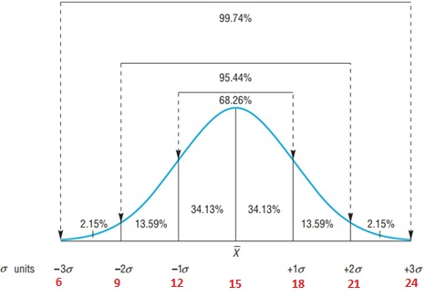

En torno a 15 esta la mayor parte de los estudiantes.

Si se eligen 10 estudiantes al azar y les pido que tomen el programa “Enciende la vela” es muy poco probable(probabilidad de 2.15%) que obtengan valores inferiores a 9(antes de programa), por lo tanto ese punto se establece como crítico:

- Si los valores(media) de la puntuación luego de tomar dicho programa estan por debajo de ese valor crítico(9) entonces rechazo la hipótesis nula. **Los resultados observados son lo suficientemente alejados de lo que uno esperaria obtener por azar.**
- Si los niveles de ansiedad(media) son de 12 por ejemplo no se alcaza a superar ese valor crítico(9) es decir esta dentro de los valores que se esperaria obtener por azar lo que se hace es aceptar la hipotesis nula. Entonces el programa no esta funcionando mejor que el azar y por lo tanto se debe revisar dicho tratamiento.

# Hipotesis nula y alternativa.

las pruebas de hipotesis se inician con una teória previa o afirmación sobre un parámetro.

**Hipótesis Nula** $H_{0}$ sugiere la no diferencia y es considerada válida hasta que se demuestre lo contrario.

Siempre contiene un signo de igualdad con respecto a un parámetro.

**Hipótesis Alternativa** $H_{1}$ se opone a la hipótesis nula, se puede considerar aceptable en caso de rechazar la hipótesis nula.

Contiene el signo de desigualdad con respecto al valor del parámetro especificado.

En otras palabras cuando planteamos que queremos evaluar la eficacia de un tratamiento en este caso para reducir la ansiedad ante examenes. Lo que se va a plantear es que los resultados que se van a obtener a partir de ese tratamiento se alejan de lo que uno esperaría obtener por azar.

Entonces si los resultados que se obtienen no se alejan sino que son bastante cercanos de lo que uno esperaria obtener por azar, eso significa que nos inclinariamos a favor de la hipótesis nula, lo que sugiere que no hay diferencia entre los grupos y que no hay diferencia entre lo que estamos obteniendo y lo que se esperaria obtener por azar. Teniendo en cuenta lo anterior planteariamos la hipotesis nula.

La hipótesis alternativa plantea que si hay diferencia entre lo que se está observando y lo que se esperaría obtener por azar y se representa como $H_{1} \not=.$ Se puede decir que hay evidencia a favor de $H_{1}$ cuando se rechaza la hipótesis nula.

Prácticamente no operamos con la hipótesis alternativa sino que nos centramos en la hipótesis nula.

# Resumiendo

Básicamente lo que se está testeando es si los resultados que se estan obteniendo de este experimento o de este estudio se asemejan o no a lo que uno esperaria obtener por azar:

- Si se asemejan entonces aceptamos $H_{0},$ es verdad que se asemejan al azar por ende el tratamiento no está funcionando o no funciono mejor que el azar.
- Si hay diferencia rechazamos la hipótesis nula y podemos inclinarnos por la hipótesis alterna que dice que el tratamiento si funciona mejor que el azar, pero ojo no se testea $H_{1}$ directamente sino que se trabaja solamente con la $H_{0}.$

# Valor crítico

Cuando se trabaja con estimación de parametros sabemos que hay resultados que se obtienen por azar.

Veamos la siguiente situación:

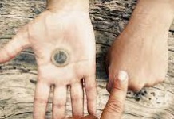

¿Poderes Mágicos?

Se hace el experimento 200 veces; adivinar la mano donde esta la moneda. Se tienen la siguientes situaciones.

- 100(50%) veces acerto.(Lo que se espera por azar)
- 120 veces acerto.(Muy cerca de lo que se espera por azar)

Entonces se debe definir un valor crítico de tal forma que si se supera ese valor crítico de aciertos entonces nos inclinamos a que se tienen poderes mágicos( Rechazo $H_{0}$), pero sino supero ese valor crítico nos inclinamos en la región de aceptación de la hipótesis nula es decir que es lo que se esperaria por azar.(No se tienen poderes mágicos)

# ¿Como fijar ese valor crítico?

Para fijar ese valor crítico hacemos uso de las distribuciones de probabilidad.

En una prueba de hipótesis podemos dividir la distribucion de muestreo en dos partes:

- **Región de rechazo** si el estadístico cae en esta región se rechaza $H_{0}.$
- **Región de NO rechazo**(Aceptación) si el estadístico cae en esta región NO se rechaza $H_{0}.$(Acepta $H_{0}$)

En la distribución normal, se conocen las áreas correspondientes, es decir se conoce la probabilidad de obtener cada valor por azar.

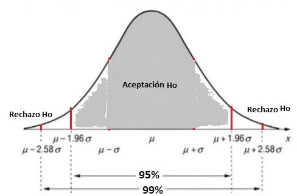

Hay un valor que se suele fijar que es de 1.96 de puntaje z (normal estándar) que significa que está a 1,96 desviaciones estándar con respecto a la media. Por abajo y arriba de casi dos desviaciones estándar está solamente el 5% del área. Esto significa que si yo eligiera un valor al azar hay un 95% de probabilidad que ese valor venga de la región de aceptación y solo un 5% de probabilidad de que ese valor que yo elijo al azar provenga de esos valores extremos(zona de rechazo), como es tan baja la probabilidad de que se elija un valor que este por fuera de ese valor crítico entonces se plantea que está es la zona de rechazo de la hipótesis nula; es decir si se obtiene un valor suficientemente alejado de un valor que se puede obtener por azar entonces rechazo la hipótesis nula.

Por otro lado si se obtiene un valor(del estadístico) del valor crítico hacia la media o de la media hacia el valor crítico es la denominada zona de aceptación de la hipótesis nula. El valor que se obtiene no es exactamente el valor esperado pero es un valor muy cercano a lo que se esperaría obtener por azar, si bien no es lo suficientemente extremo para rechazar $H_{0}$, lo que se hace es no rechazar $H_{0}$ es decir acepto la $H_{0}.$

# Para el ejemplo de ansiedad.

Si el valor promedio de ansiedad es 15 y supongamos que se ponen en función de las desviaciones estándar, se hace 1,96 desviaciones estandar por debajo(1,96$\sigma$=1,96(3)=9,12) entonces se hace que ese valor(9,12) sea el valor crítico y en función de ese valor crítico se establece la zona de rechazo y la zona de aceptación.

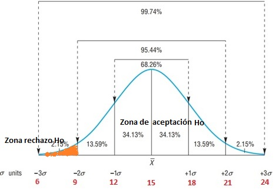

Entonces si despues de tomar el El programa de entrenamiento “Enciende la vela” los estudiantes obtienen niveles de ansiedad por debajo de 9.12 es decir que supera ese valor crítico entonces rechazo $H_{0}.$ Es decir que dicho tratamiento no es lo mismo que el azar es decir que genera una diferencia significativa con respecto al azar.

Por el contrario si al llevar a cabo dicho tratamiento se observa que los estudiantes tienen valores de ansiedad que no superan ese valor crítico, supongamos 12,3 entonces no rechazo la hipótesis(Acepto $H_{0}$) es decir que el tratamiento no es mejor que el azar.

# Error tipo I.

Supongamos que se tomo una muestra aleatoria se aplico el tratamiento y se obtuvo un valor de 8 entonces se rechaza $H_{0},$ sin embargo existe la probabilidad de que ese grupito de estudiantes que se eligio para hacer el estudio eran estudiantes que de todos modos iban a tomar valores bajos si esto ocurre estamos en la presencia de un **error tipo I Rechazar** $H_{0}$ **siendo cierta.**

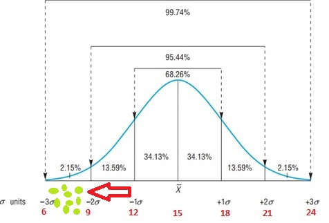

Es decir el tratamiento no funcionaba no bajaba la ansiedad, pero justo por casualidad se eligio una muestra de esos 10 estudiantes que tenian baja ansiedad y por eso estamos obteniendo resultados tan bajos, pero no es porque el tratamiento funciona en realidad el tratamiento no genera efectos distintos del azar. En relidad $H_{0}$ es cierta pero se rechaza por un capricho del azar justo se eligio personas que ya iban a tener niveles de ansiedad.

**La probabilidad de cometer un error tipo I, se suele llamar significancia de la prueba y se denota como** $\alpha.$

# Error tipo II.

**Aceptar la $H_{0}$ cuando en realidad es falsa, debería rechazarla.**

El tratamiento si funciona, es decir se aplica el tratamiento a un grupo de estudiantes pero por determinado factor:

- Muestra pequeña.
- El tratamiento funciona pero no es lo suficientemente fuerte.
- Por diversos factores no se alcanza a superar ese valor crítico.

Supongamos que el valor crítico es 9 y luego del tratamiento su nivel de ansiedad es 10, como no supera el valor crítico, no rechazo $H_{0}$ sino que la acepto y digo el tratamiento no funciona y puede ser que en realidad este ocurriendo un error tipo II, es decir **el tratamiento funciona pero no alcanzo a ese valor crítico.**

Lo bueno es que el error tipo I, se puede cuantificar porque depende del valor crítico, es decir de acuerdo a donde se fije el valor crítico se obtiene el error tipo I.

Esto significa que el **NIVEL DE CONFIANZA ES DEL 95%**, esto significa que con un 95% de probabilidad no son resultados que uno esperaria obtener por azar, si elijo un valor por azar el 95% de las veces va venir de la zona de aceptación, y solamente un 5% de la veces va venir de los extremos.

# Error Tipo I y Error Tipo II.

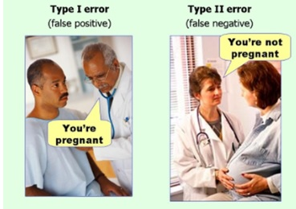

# ¿Que pasa si se mueve el valor crítico?

Si el valor crítico se vuelve mas pequeño, es decir si se disminuye la probabilidad del error tipo I ($\alpha$), se tiene mayor riesgo de cometer un error de tipo II.

# Valor de probabilidad o valor p.

El valor de probabilidad asociado al resultado muestral, que también se llama valor p. Se trata de la probabilidad de observar en la experiencia un resultado igual o más extremo que el obtenido a partir de los datos muestrales, bajo el supuesto de que la hipótesis nula es cierta. Es decir, la probabilidad de hallar un resultado como el que se encontró o más extremo que él, solo por azar. Un valor p pequeño indica que el resultado observado (o resultados más extremos que él) son poco probables bajo el supuesto de hipótesis nula cierta, por lo cual hay evidencia en contra de la hipótesis nula.

Cuanto más pequeño es el valor p, tanta más evidencia hay para rechazar $H_{0}$. Por el contrario, un valor p grande indica que el resultado observado es muy probable bajo el supuesto de hipótesis nula cierta, lo que no aporta evidencia en contra de la hipótesis nula y conduce a no rechazarla. Esta manera de indicar cuán esperable sería lo que hemos observado si H0 fuera cierta, puede vincularse con nuestro razonamiento anterior, comparando el valor p con el nivel de significación fijado de antemano.

Así resultan dos posibilidades:

Si el valor p es menor que el nivel de significación establecido $(p<\alpha)$: se rechaza la hipótesis nula y se describe como **“un resultado estadísticamente significativo”**. Esto quiere decir que la probabilidad de haber hallado este resultado por azar es pequeña, por lo que se trata de un efecto o diferencia que muy difícilmente se puede atribuir al azar.

Si el valor p es mayor que el nivel de significación establecido $(p>\alpha)$: no se rechaza la hipótesis nula y se expresa como **“un resultado no estadísticamente significativo”**. Lo que expresa que la probabilidad de haber hallado este resultado por azar es mayor que el máximo establecido, por lo que es razonable atribuirlo al azar, es decir a la variabilidad propia de los resultados muestrales.

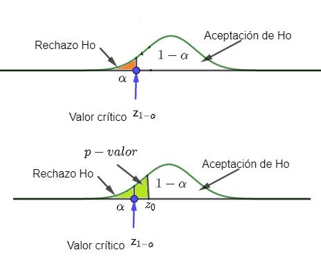

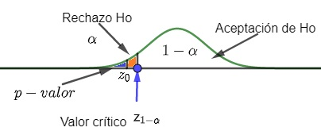

Donde $z_{0}$ es el valor del estadístico calculado teniendo en cuenta la muestra. Observamos que:

- En la segunda gráfica p-valor $> \alpha$, por lo tanto no se rechaza $H_{0},$ (se acepta $H_{0}$, se rechaza $H_{1},$) se expresa como “un resultado no estadísticamente significativo”. Lo que expresa que la probabilidad de haber hallado este resultado por azar es mayor que el máximo establecido, por lo que es razonable atribuirlo al azar, es decir a la variabilidad propia de los resultados muestrales.
- En la tercera gráfica p-valor $< \alpha$, se rechaza $H_{0},$ se acepta $H_{1},$ es decir se describe como “un resultado estadísticamente significativo”. Esto quiere decir que la probabilidad de haber hallado este resultado por azar es pequeña, por lo que se trata de un efecto o diferencia que muy difícilmente se puede atribuir al azar.

**El valor p está indicando cual es la probabilidad de que esos resultados que se estan obteniendo (de la muestra) se deban al azar.**

Intuitivamente, es el nivel de credibilidad de la hipótesis nula, el cual depende de $\alpha.$ De manera formal es la probabilidad de obtener una discrepancia(ir al contrario) mayor o igual a la encontrada en la muestra cuando $H_{0}$ es cierta.

El p-valor tambien se llama significación(significancia) del contraste. ** No se debe confundir con el nivel de significación(significancia) $\alpha$ del contraste.**

En los siguientes artículos se puede ver la aplicación.

Artículo 1.

**Depresión, ansiedad e ira en adultos que sufrieron ataque al miocardio: un estudio de caso-control**

Artículo 2.

**Effectiveness of a training program to decrease cognitive manifestations of anxiety in college freshmen before academic exams**

# Para resumir

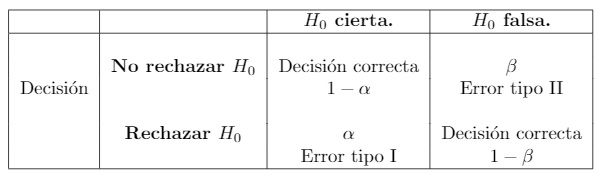

Luego :

- P(Se cometa el error tipo I)=$\alpha$ (nivel de significación), es decir

$\alpha =$ P(Rechazar $H_{0}|H_{0}$ es verdadera.)

- P(NO se cometa el error tipo I)=$1 - \alpha$ (nivel de confianza)

$1 - \alpha =$ P(No rechazar $H_{0}|H_{0}$ es verdadera.)

- P(Se cometa el error tipo II)=$\beta$, es decir

$\beta =$ P(NO rechazar $H_{0}|H_{0}$ es falsa.)

- P(NO se cometa el error tipo II)=$1 - \beta$ (Potencia de la prueba)

$1 - \beta =$ P(Rechazar $H_{0}|H_{0}$ es falsa.) **esto se llama potencia**

# ¿Que es la potencia estadística?

Supongamos que se esta desarrollando un tratamiento(programa) para disminuir la ansiedad ante examenes o un protocolo para que los estudiantes puedan preparse en menos horas de estudio para un examen o un tratamiento para bajar de peso, etc.

Supongase que se forman dos grupos: un grupo control y el otro a quien se le administrará el tratamiento.

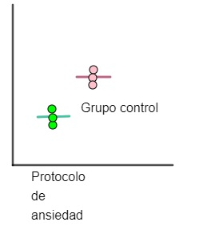

La intensión es análizar como se comportan las medias si se asemejan bastante esta muy cerca la una de la otra y cuando se aplica una prueba de hipótesis, por ejemplo una prueba t para comparar grupos, lo que arroja esa prueba de hipótesis es un valor p son superior a 0.05 (por ejemplo 0.27) y por lo tanto se aceptaria la hipótesis nula.

**Quiere decir que hay una probabilidad elevada de que esas leves diferencias que se observan entre los grupos se deban simplemente al azar**

En otras palabras esas diferencias no hacen que el grupo que recibe tratamiento tenga una media más baja porque el tratamiento es eficaz sino que estas diferencias se podrían explicar simplemente por azar, entonces como el valor p que se obtiene supera la probabilidad del punto de corte de 0.05 se acepta $H_{0}.$

Es decir inclinarse por la idea de que las diferencias que se están observando entre los dos grupos, observaciones leves simplemente se deben al azar, dicho de otra forma lo que se plantea es que se distribuyen de manera similar(misma distribución).

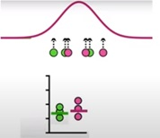

Las diferencias que se observan en realidad se deben a un error en el muestreo y en un grupo justo elegi un par de personas que estaban cerca del promedio para abajo y otro grupo elegi personas del promedio para arriba, pero los valores del los 6 provienen de la misma distribución de datos, entonces es posible que este observando una diferencia entre los dos grupos no porque haya una diferencia sino por una cuestión de muestreo.

**Error tipo II: aceptar** $H_{0}$ **cuando se debe rechazar** , lo cual puede ocurrir de la siguiente forma: imagine que hay dos distribuciones distintas; los estudiantes que reciben el tratamiento tiene una distribución que se diferencia de los estudiantes que no recibe el tratamiento.

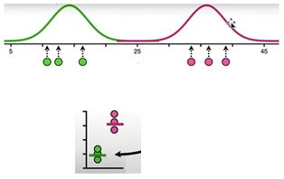

Entonces si se eligio una muestra de cada distribución se obtienen valores cercanos a la media de cada distribución por separado y si son distribuciones que se diferencian que estan bastante alejadas una de otra entonces al hacer el muestreo se deberia tener la tercera gráfica de la figura, es decir medias que están bastante alejadas y en este caso se obtendria un valor p inferior a $\alpha$ y por lo tanto serechazariá correctamente $H_{0}.$

En otras palabras la diferencia que se esta observando es poco probable que se deba al azar, lo más probable es que haya una diferencia entre las dos distribuciones que se estan midiendo.

Pero puede ocurrir por azar que justo elegimos los casos que estan en la parte donde se solapan las distribuciones es decir datos atípicos grandes y pequeños.

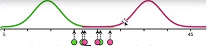

Es decir se estaria diciendo que los datos provienen de una misma distribución, pero se debe a un error de muestreo(azar) porque en realidad provienen de dos distribuciones diferentes y se dio la mala suerte de seleccionar la muestra de casos que se solapan y hace que la diferencia sea muy pequeña.

Se obtendría un valor p superior a 0.05 y por lo tanto se aceptaria incorrectamente la hipótesis nula (Error tipo II.)

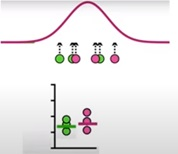

En este caso se esta cometiendo un error tipo II, ya que se deberia rechazar la hipótesis nula, pues los datos no provienen de una distribución que es igual sino que provienen de dos distribuciones distintas y que justo se presento el hecho de tomar esos casos atípicos donde se estan solapando(Se acepta $H_{0}$ cuando en realidad se debe rechazar) ese es el error tipo II.

La probabilidad de cometer un error tipo II, se denota como $\beta.$